# Visualización

La visualización es una pieza fundamental del flujo de trabajo con datos, tanto para explorar como para explicar/comunicar resultados e ideas. Es decir, dominar las herramientas de visualización resulta imprescindible a la hora de hacer una análisis de datos.

Una gráfica excelente, presenta datos interesantes de forma bien diseñada: es una cuestión de fondo, de diseño, y estadística. Se compone de ideas complejas comunicadas con claridad, precisión y eficiencia. Es lo que da al espectador la mayor cantidad de ideas, en el menor tiempo, con la menor cantidad de tinta, y en el espacio más pequeño. Es casi siempre multivariado. Una excelente gráfica debe decir la verdad acerca de los datos. (Tufte, 1983)

## Representaciones históricas

- Primer gráfico estadístico conocido:

En 1644, se cree que Michael Florent Van Langren, astrónomo, proporcionó la primera representación visual de datos estadísticos. Esto marcó un cambio significativo desde los mapas puramente geográficos a la visualización de datos abstractos. El siguiente gráfico lineal unidimensional muestra las doce estimaciones conocidas en la época de la diferencia de longitud entre Toledo y Roma, así como el nombre de cada astrónomo que proporcionó la estimación.

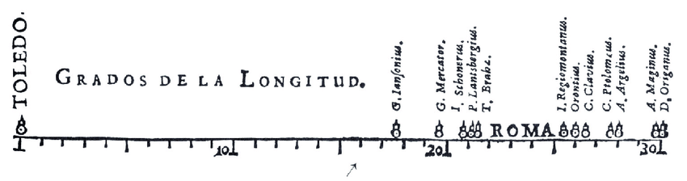

- Campaña de Napoleón contra Rusia

La famosa visualización de Charles Joseph Minard de la marcha de Napoleón sobre Moscú, ilustra los principios de una buena gráfica. Tufte señala que esta imagen “bien podría ser el mejor gráfico estadístico jamás dibujado”, y sostiene que “cuenta una historia rica y coherente con sus datos multivariados, mucho más esclarecedora que un solo número que rebota en el tiempo”. Se representan seis variables: el tamaño del ejército, su ubicación en una superficie bidimensional, la dirección del movimiento del ejército y la temperatura en varias fechas durante la retirada de Moscú“.

[figure not shown]

- John Snown

Plano de Londres que permitió entender la peste del cólera - John Snown (1854)

A mediados del siglo XIX, la creencia general presuponía que el cólera se propagaba a través del miasma en el aire. John Snow fue un médico nacido en 1813, célebre por su contribución al desarrollo de la anestesia. Él pensaba que el cólera se propagaba, no a través del aire, sino por el agua contaminada.En 1854 empezó a registrar los casos de cólera del barrio de Soho, sobre un mapa centrado en torno a 13 fuentes: cada muerte era anotada sobre el lugar de residencia. En total, 578 muertes y el resultado dejaba lugar a pocas dudas: casi todas se concentraban alrededor de una **fuente en Broad Street**. Hoy, su mapa es considerado pionero en el uso del método geográfico para estudiar una epidemia. Pero además, cambió para siempre cómo percibimos las visualizaciones de datos: no sólo como un apoyo clarificador a un modelo ya conocido, sino como sustento y prueba del mismo.

[figure not shown]

## Gráficos

En análisis de datos los gráficos son utilizados para diferentes fines:

- Para visualizar y entender los datos.
- Para encontrar patrones.
- Para depurar o limpiar los datos.
- Se pueden sugerir estrategias para realizar modelos.
- Para comunicar resultados obtenidos.

R permite realizar gráficos en una dimensión, en dos o en tres dimesiones.

**Gráficos en una dimensión**

- Histogramas
- Boxplots
- Gráficos de dispersión.
- Gráficos de barras.
- Etc.

**Algunos gráficos posibles en dos dimensiones**

- Scatterplots
- Smooth scatterplots
- Gráficos superpuestos

Para trabajar en dos dimesiones se pueden utilizar además colores, tamaños y formas.

Existen funciones gráficas contenidas en la base de R. Para funciones gráficas o visualizaciones más complejas se requieren de otros paquetes, como son:

[figure not shown]

La gran comunidad de usuarios de R disponibiliza sus creaciones e incluso trabajan en extensiones que amplien la potencialidad de sus paquetes.

- [The R Graph Gallery](https://www.r-graph-gallery.com/)
- [Top 50 plots](http://r-statistics.co/Top50-Ggplot2-Visualizations-MasterList-R-Code.html)

## Paquete ggplot2

Este paquete permite generar rápidamente gráficos exploratorios, así como crear figuras complejas de alta calidad.

Tiene una gramática propia, tal que un gráfico puede ser elaborado a partir de la combinación de capas, las cuales pueden ser diferentes bases de datos y objetos gráficos (puntos, líneas, barras, etc).

Las capas no tienen un orden estricto, salvo la primera que debe ser **ggplot()**, función que inicializa un gráfico. Luego se asociará el dataframe principal (ya que un mismo gráfico puede aceptar información de distintos datasets), y las **aesthetics**.

### aesthetics

Se definen con **aes()** Significado de aesthetic en ggplot: “algo que se puede ver”. Cada geom acepta un conjunto de aesthetics. Ejemplos:

- position (i.e., en el eje “x” y “y”)
- color (color “exterior”)
- fill (color “interior”)
- shape (tipos de puntos)
- linetype (tipos de líneas)
- size (tamaño de los elementos)
- etc.

Para ejemplificar vamos a utlizar la base de datos “paises”.

```r
head(paises)
```

|  | Pais | Poblacion_2020 | Cambio_porc_anual | Cambio_neto_anual | Densidad | Area | Migrantes | Tasa_de_crecimiento | Edad_promedio | Poblacion_urbana | Porc_mundial | Code | Continente | PBI | Poblacion |
| --- | --- | --- | --- | --- | --- | --- | --- | --- | --- | --- | --- | --- | --- | --- | --- |
| 1 | Afghanistan | 39074280 | 2.33 | 886592 | 60 | 652860 | -62920 | 4.6 | 18 | 25 | 0.50 | AFG | Asia | 19469 | 34656032 |
| 2 | Albania | 2877239 | -0.11 | -3120 | 105 | 27400 | -14000 | 1.6 | 36 | 63 | 0.04 | ALB | Europe | 11864 | 2876101 |
| 3 | Algeria | 43984569 | 1.85 | 797990 | 18 | 2381740 | -10000 | 3.1 | 29 | 73 | 0.56 | DZA | Africa | 159049 | 40606052 |
| 4 | American Samoa | 55169 | -0.22 | -121 | 276 | 200 | NA | NA | NA | 88 | 0.00 | ASM | America | 658 | 55599 |
| 5 | Andorra | 77287 | 0.16 | 123 | 164 | 470 | NA | NA | NA | 88 | 0.00 | AND | Europe | 2859 | 77281 |
| 6 | Angola | 33032075 | 3.27 | 1040977 | 26 | 1246700 | 6413 | 5.6 | 17 | 67 | 0.42 | AGO | Africa | 95335 | 28813463 |

Primero dibujamos el esquema del gráfico solamente, sin observaciones, no se agrega ninguna capa.

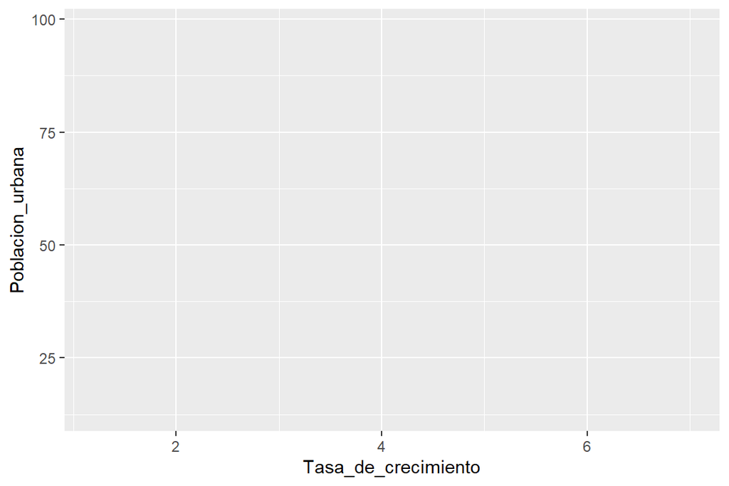

```r
ggplot(paises, aes(x=Tasa_de_crecimiento, y=Poblacion_urbana))
```

Comenzaremos a agregar las capas.

### geoms

Objetos geométricos. Son la representación visual de las observaciones. En general son los que le dan el nombre al tipo de gráfico. La [lista de “geoms”](https://ggplot2.tidyverse.org/reference/#section-layer-geoms) se encuentra en constante aumento.

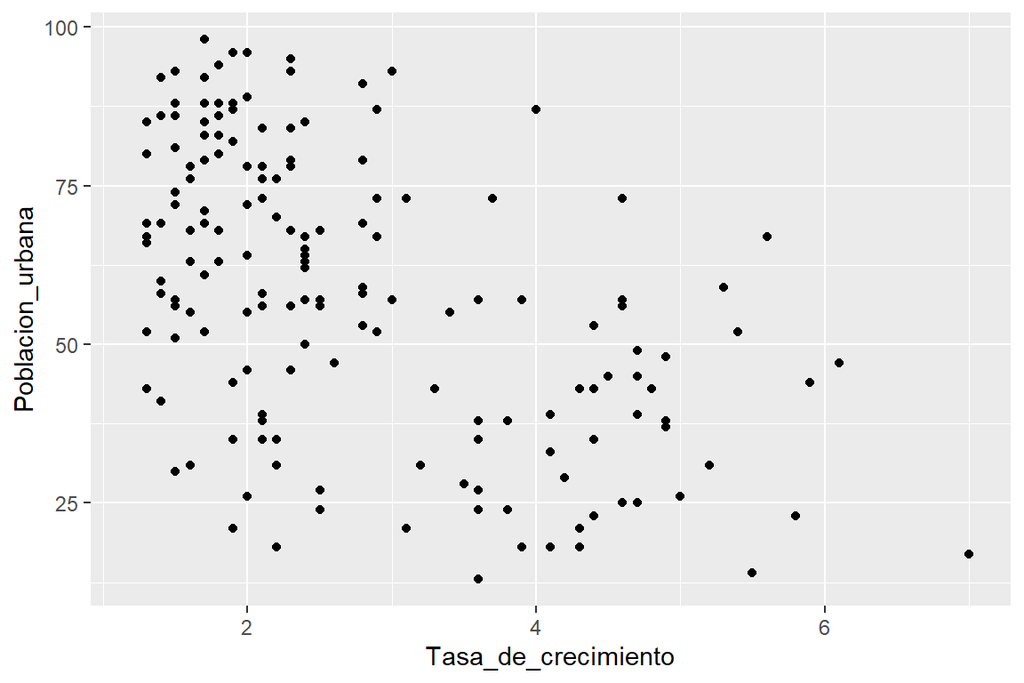

```r
ggplot(paises, aes(x=Tasa_de_crecimiento, y=Poblacion_urbana)) + geom_point()
```

El mismo gráfico se puede realizar de la siguiente manera:

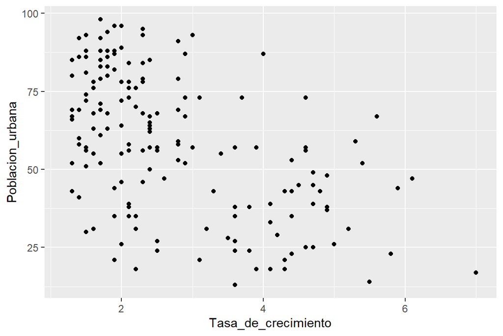

```r
ggplot(paises) + geom_point(mapping = aes(x=Tasa_de_crecimiento, y=Poblacion_urbana))
```

Se puede agregar una tercera variable a un diagrama de dispersión bidimensional asignándolo a un parámetro estético. Un parámetro estético (o estética) es una propiedad visual de los objetos de un gráfico. En este caso agregamos los “continentes” con diferentes colores.

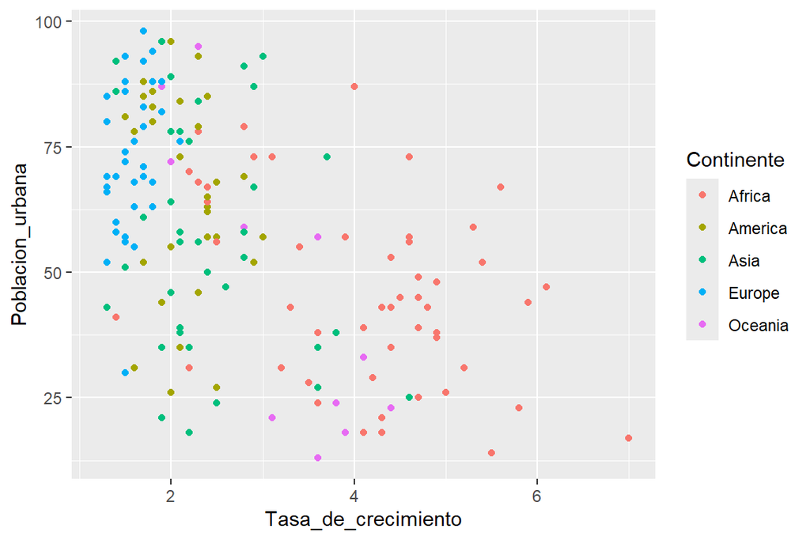

```r
ggplot(paises, aes(x=Tasa_de_crecimiento, y=Poblacion_urbana, color = Continente)) + geom_point()
```

Además se pueden configurar los colores de cada nivel a partir de la función **scale_colour_manual**

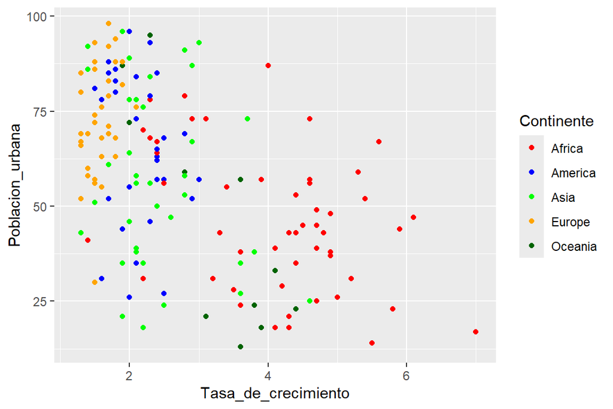

```r
ggplot(paises, aes(x=Tasa_de_crecimiento, y=Poblacion_urbana, color = Continente)) + geom_point() + scale_color_manual(values = c("red", "blue", "green", "orange", "darkgreen"))
```

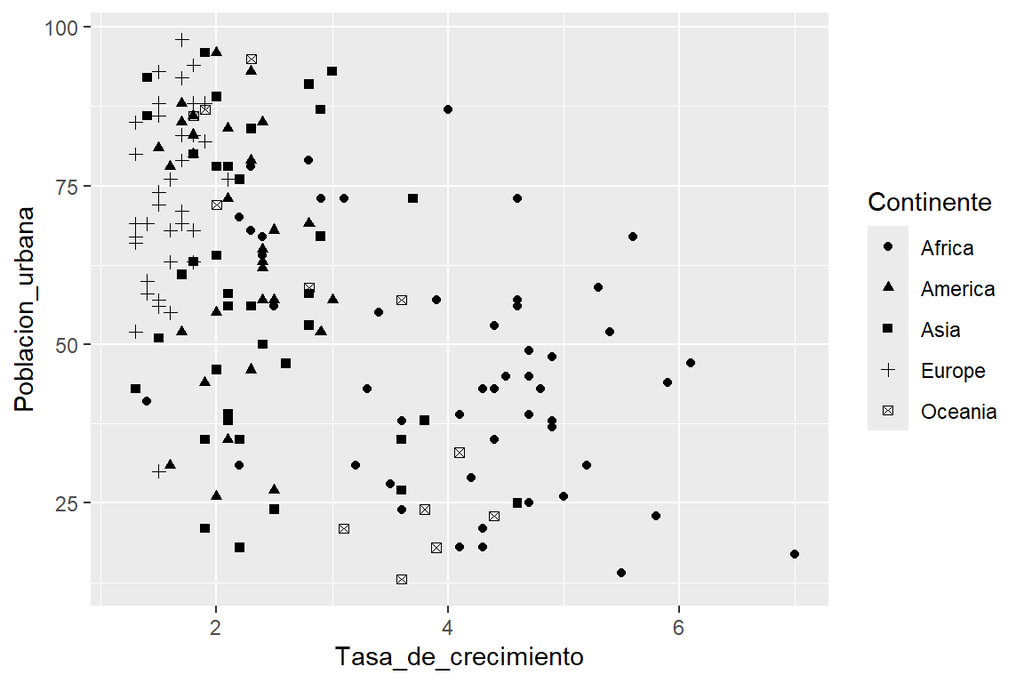

```r
ggplot(paises, aes(x=Tasa_de_crecimiento, y=Poblacion_urbana, shape = Continente)) + geom_point()
```

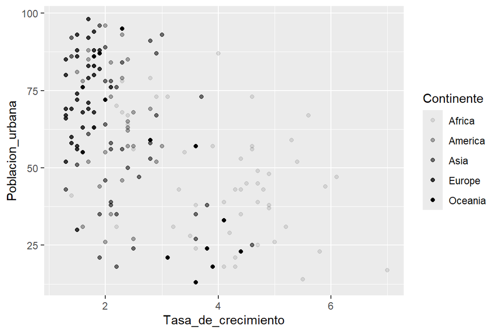

```r
ggplot(paises, aes(x=Tasa_de_crecimiento, y=Poblacion_urbana, alpha =  Continente)) + geom_point()
```

Los puntos de los gráficos de dispersión pueden ser modificados según la siguiente refererncia:

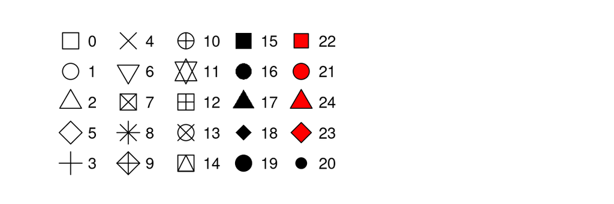

Por ejemplo:

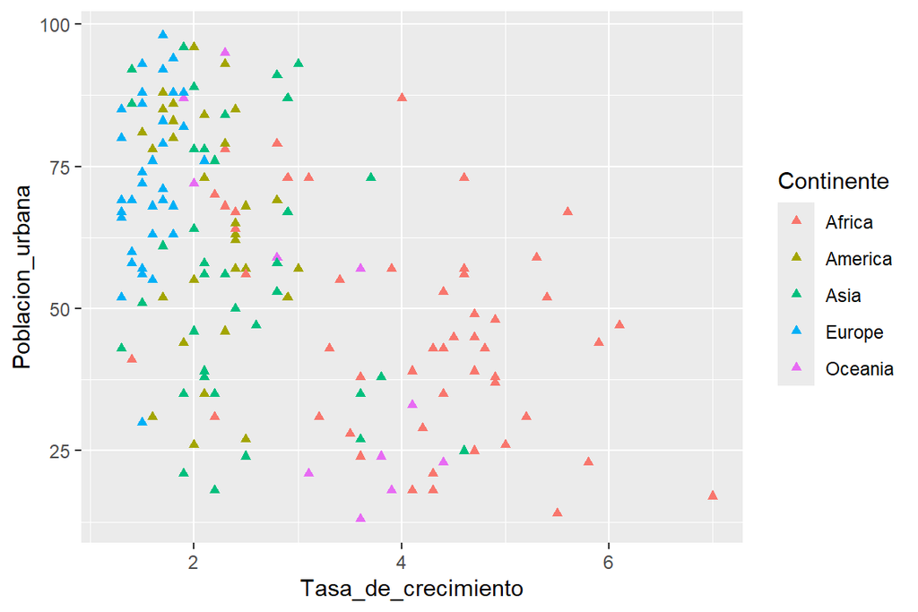

```r
ggplot(paises, aes(x=Tasa_de_crecimiento, y=Poblacion_urbana, color =  Continente)) + geom_point(shape = 17)
```

Con **geom_smooth()** se le puede agregar la línea de tendencia

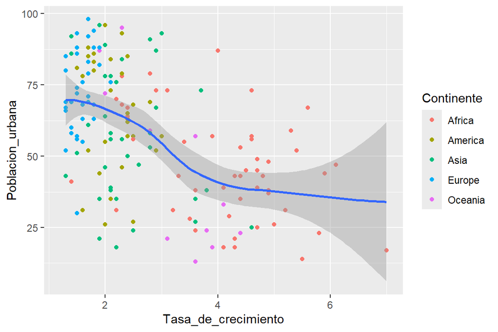

```r
ggplot(paises, aes(x=Tasa_de_crecimiento, y=Poblacion_urbana)) +
       geom_point(aes(color = Continente)) + geom_smooth()
```

Con **geom_text()** se colocan las etiquetas de los puntos. Con los argumentos **hjust** y **vjust** asignamos las coordenadas de las posiciones de los nombres.

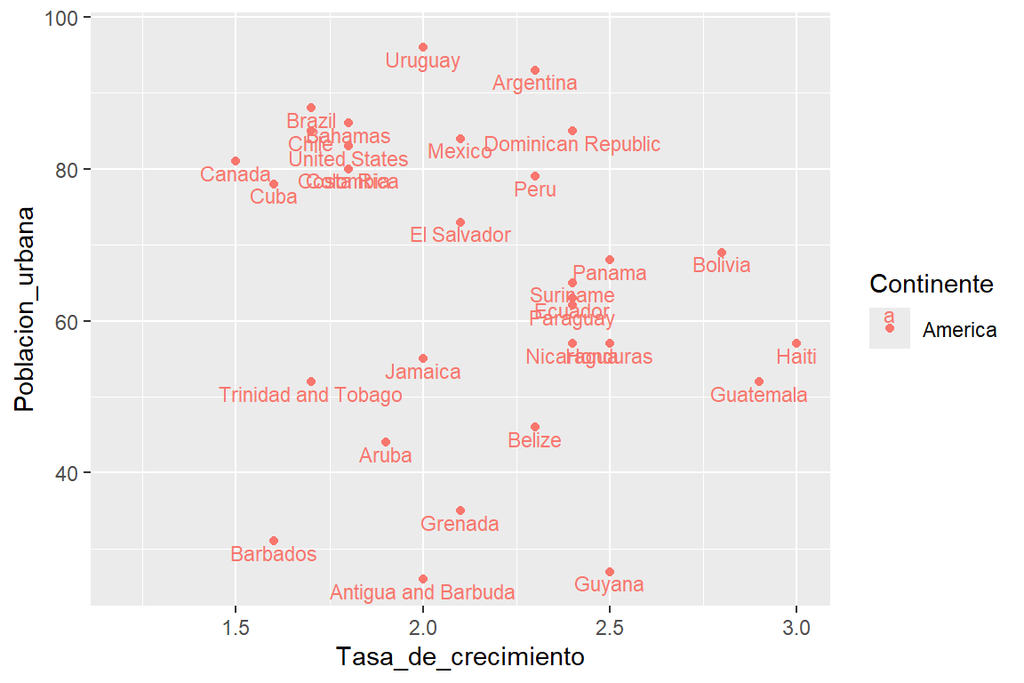

```r
america <- paises %>% filter(Continente == "America")

ggplot(america, aes(x=Tasa_de_crecimiento, y=Poblacion_urbana,
                   color = Continente)) + geom_point()+
               geom_text(aes(label=Pais), size = 3, hjust=0.5, vjust=1.2)
```

También la función **ggplot** se puede ejecutar utilizando la librería **dply**

Por ejemplo, hacemos el mismo gráfico de “Tasa de crecimiento” vs. “Población urbana” segmentando por continente.

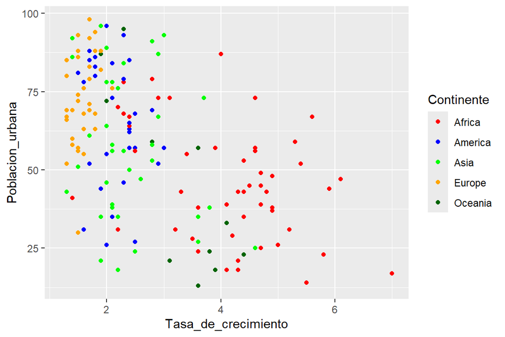

```r
paises %>%
ggplot(aes(x=Tasa_de_crecimiento, y=Poblacion_urbana, color = Continente)) + geom_point() + scale_color_manual(values = c("red", "blue", "green", "orange", "darkgreen"))
```

Hacemos el mismo gráfico para comparar solo América y Europa

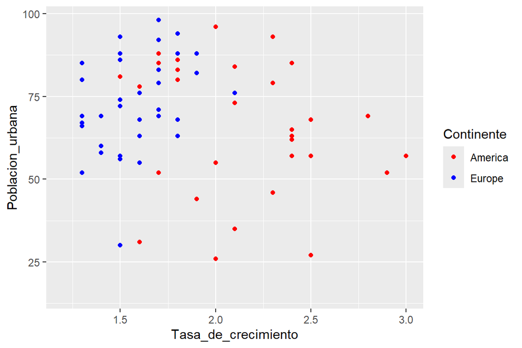

```r
paises %>% filter(Continente %in% c("America", "Europe")) %>%
           ggplot(aes(x=Tasa_de_crecimiento, y=Poblacion_urbana, color = Continente)) +
           geom_point() +
           scale_color_manual(values = c("red", "blue", "green", "orange", "darkgreen"))
```

### facets

Las facetas o “facets” permiten dividir el mismo gráfico en diferentes niveles de un **factor**.

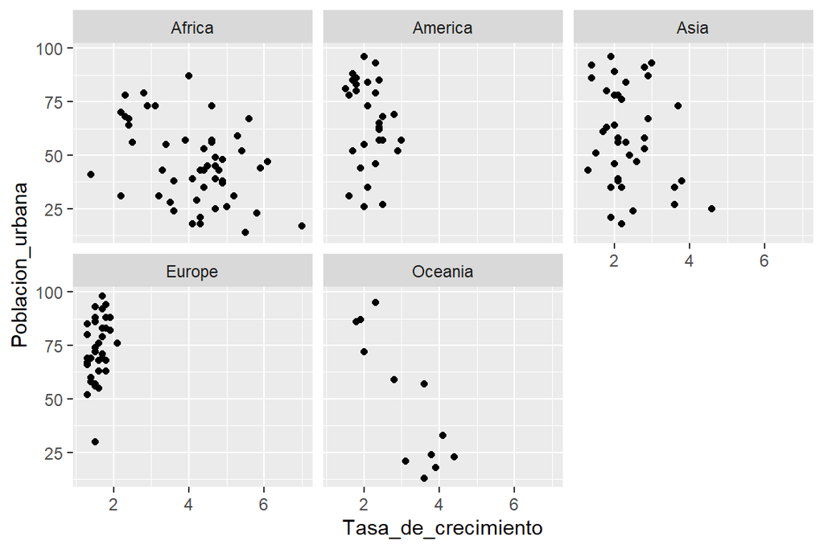

```r
ggplot(paises, aes(x=Tasa_de_crecimiento, y=Poblacion_urbana)) +
                    geom_point()+
                    geom_point()+
                    facet_wrap(~Continente)
```

### theme

Los temas (theme) son un conjunto de opciones predefinidas sobre la apariencia de los objetos en ggplot. El tema por defecto del ggplot dibuja el gráfico sobre un fondo gris. Por ejememplo, podemos cambiarlo a blanco añadiendo el comando **theme_bw()**.

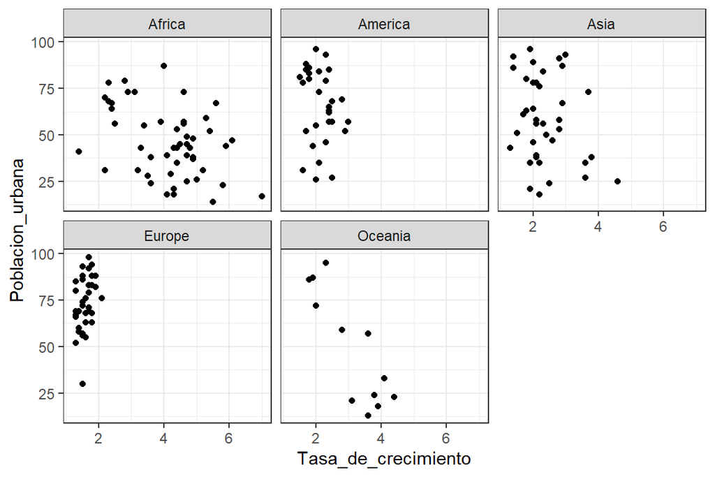

```r
ggplot(paises, aes(x=Tasa_de_crecimiento, y=Poblacion_urbana)) +
                   geom_point() +
                   geom_point() +
                   facet_wrap(~Continente)  +
                   theme_bw()
```

En el siguiente gráfico se utliza la función **theme** para cambiar la apariencia y ajustar la posición del título.

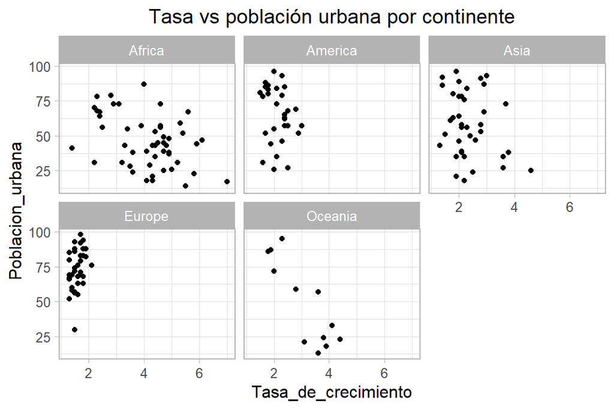

```r
ggplot(paises, aes(x=Tasa_de_crecimiento, y=Poblacion_urbana)) +
                   geom_point() +
                   geom_point() +
                   facet_wrap(~Continente)  +
                   theme_bw() +
                   theme_light(base_size = 12) +
                   ggtitle("Tasa vs población urbana por continente") +
                     theme(plot.title = element_text(hjust = 0.5))
```

Algunas opciones de la estética de fondo a partir de la función **theme**

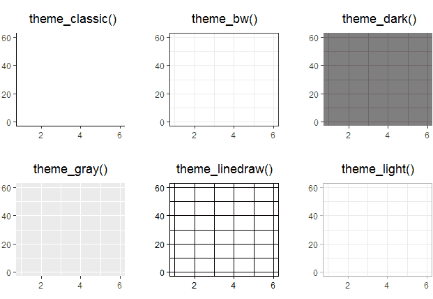

### statistics

Permite realizar transformaciones estadísticas para que sean utilizadas en la visualización. Esta funciones, comunmente son utilizadas en conjunción con **geom_**. En el siguiente gráfico vamos a representar la tasa de crecimiento promedio por contiente. Además, con los argumentos **xlab** e **ylab** colocamos los nombres a los ejes x e y respectivamente.

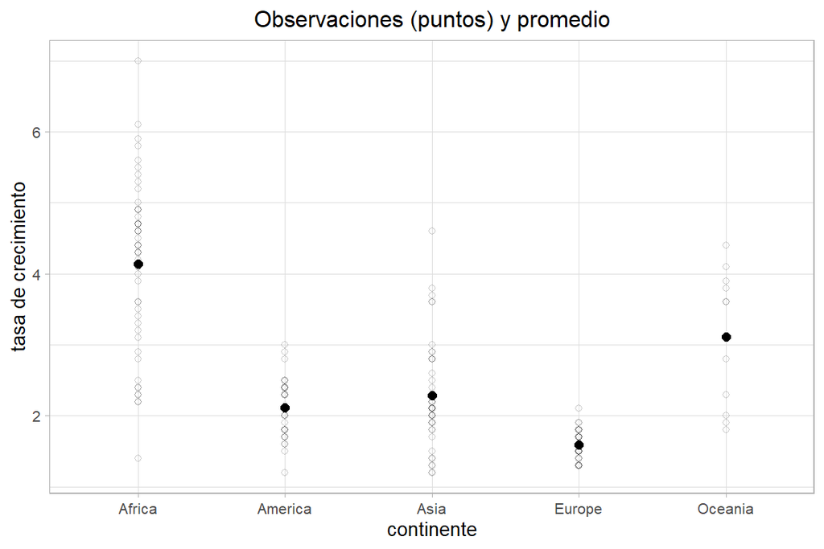

```r
p1 <- ggplot(paises, aes(x=Continente, y=Tasa_de_crecimiento)) +
                     geom_point(shape = 1, alpha=0.2)+
                     stat_summary(fun = mean, geom = "point",
                     size = 2)+
                     theme_light(base_size = 10)+
                     ggtitle("Observaciones (puntos) y promedio") +
                     theme(plot.title = element_text(hjust = 0.5))+                                 xlab("continente") +
                     ylab("tasa de crecimiento")
p1
```

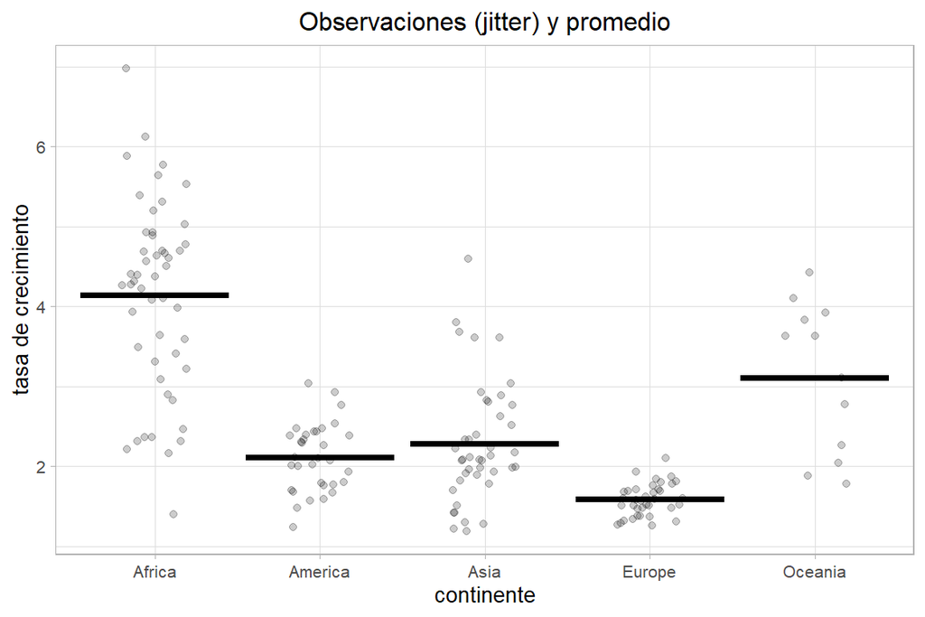

```r
p2 <- ggplot(paises, aes(x=Continente, y=Tasa_de_crecimiento)) +
                     geom_jitter(width = 0.2, alpha=0.2)+
                     stat_summary(fun.y = mean,
                     geom = "crossbar",
                     size = 0.5)+
                     theme_light(base_size = 10)+
                     ggtitle("Observaciones (jitter) y promedio") +
                     theme(plot.title = element_text(hjust = 0.5)) +
                     xlab("continente") +
                     ylab("tasa de crecimiento")
p2
```

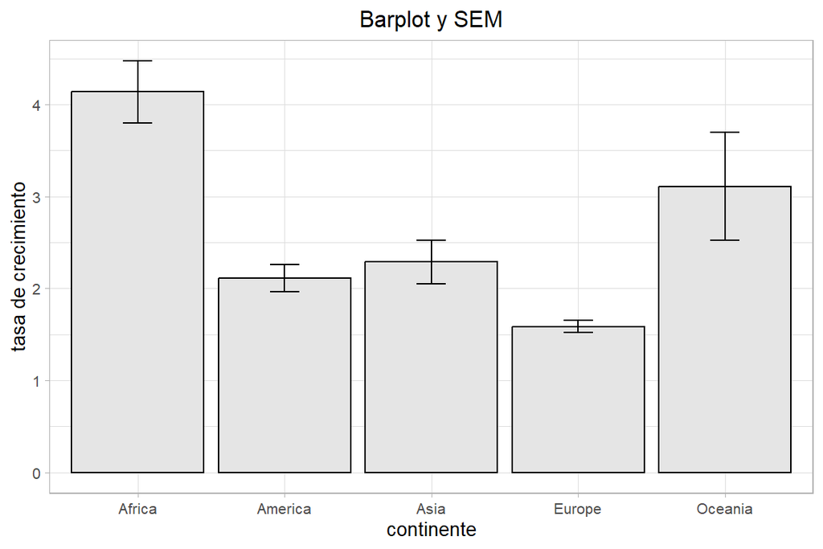

```r
p3 <- ggplot(paises, aes(x=Continente, y=Tasa_de_crecimiento)) +
                     stat_summary(fun=mean, geom="bar", colour="black", fill="grey90")+
                     stat_summary(fun.data=mean_cl_normal, geom="errorbar", width=0.2) +
                     theme_light(base_size = 10) +
                     ggtitle("Barplot y SEM") +
                     theme(plot.title = element_text(hjust = 0.5)) +
                     xlab("continente") +
                     ylab("tasa de crecimiento")

p3
```

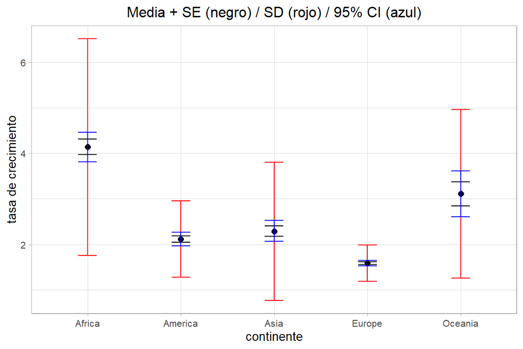

```r
p4 <- ggplot(paises, aes(x=Continente, y=Tasa_de_crecimiento)) +
                     stat_summary(fun ="mean", geom="point", size=2) +
                     stat_summary(fun.data = mean_se, geom = "errorbar", width=0.2)+
                     stat_summary(fun.data= mean_sdl, geom = "errorbar", color="red", width=0.2)+
                     stat_summary(fun.data = mean_cl_boot, geom = "errorbar", color="blue", width=0.2)+
                     theme_light(base_size = 10)+
                     ggtitle("Media + SE (negro) / SD (rojo) / 95% CI (azul)") +
                     theme(plot.title = element_text(hjust = 0.5)) +
                     xlab("continente") +
                     ylab("tasa de crecimiento")
p4
```

Con **plot_grid** de la librería **cowplot** podemos visualizar todos los gráficos juntos. Además, vamos a rotar los nombres del eje x para poder leerlos.

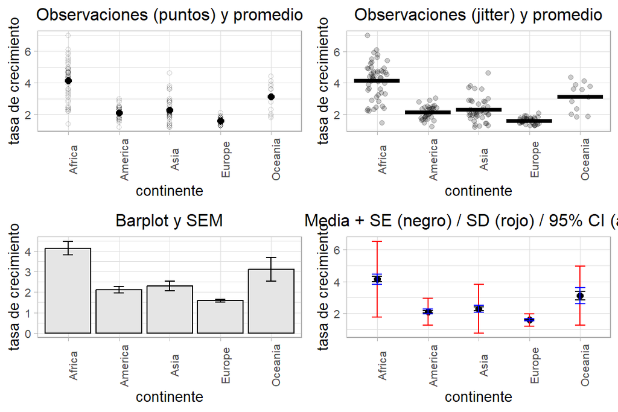

```r
cowplot::plot_grid(p1 + theme(axis.text.x = element_text(angle = 90)),
                   p2 + theme(axis.text.x = element_text(angle = 90)),
                   p3 + theme(axis.text.x = element_text(angle = 90)),
                   p4 + theme(axis.text.x = element_text(angle = 90)),
                   ncol = 2, nrow = 2)
```

## Gráficos para distintos tipos de variables

[Galería de gráficos para elegir el que se corresponda con la variable o variables en estudio](https://www.data-to-viz.com/)

### Variables categóricas

Para este tipo de variables se pueden realizar gráficos de barras

```r
library(openxlsx)
autos <- read.xlsx("Bases de datos/autos.xlsx")
head(autos)
```

|  | Rendimiento.(millas.por.galon) | Cilindrada | HP | Peso | Aceleracion | Modelo | Marca | X8 |
| --- | --- | --- | --- | --- | --- | --- | --- | --- |
| 1 | 18 | 8 | 130 | 3504 | 12.0 | 70 | chevrolet | NA |
| 2 | 14 | 8 | 220 | 4354 | 9.0 | 70 | chevrolet | NA |
| 3 | 15 | 8 | 150 | 3761 | 9.5 | 70 | chevrolet | NA |
| 4 | 10 | 8 | 200 | 4376 | 15.0 | 70 | chevrolet | NA |
| 5 | 28 | 4 | 90 | 2264 | 15.5 | 71 | chevrolet | NA |
| 6 | 17 | 6 | 100 | 3329 | 15.5 | 71 | chevrolet | NA |

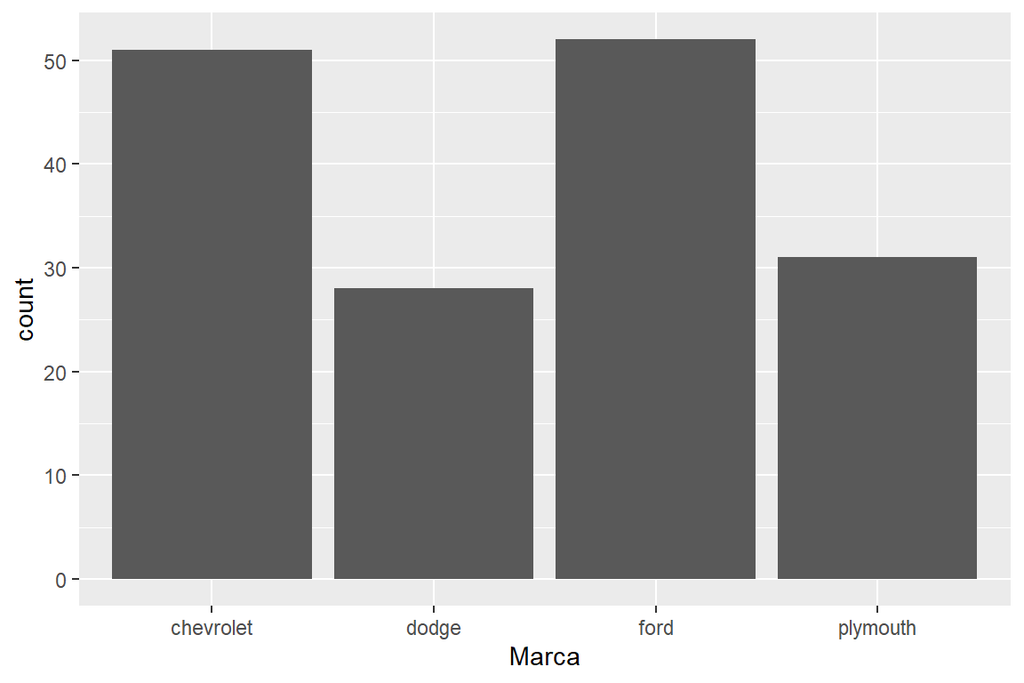

```r
ggplot(data = autos, aes(x = Marca)) +
       geom_bar()
```

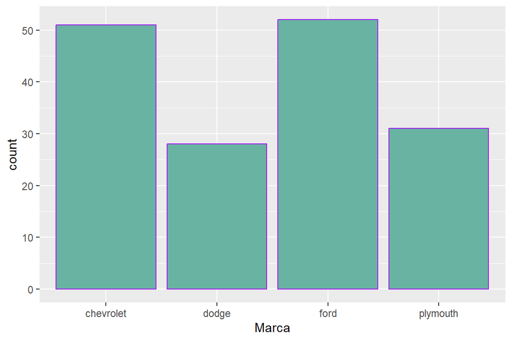

```r
ggplot(data = autos, aes(x = Marca)) +
       geom_bar(color="purple", fill="#69b3a2")
```

Agregamos la variable “Cilindrada” para visualizar las diferencias en cada categoría de la variable “Marca”

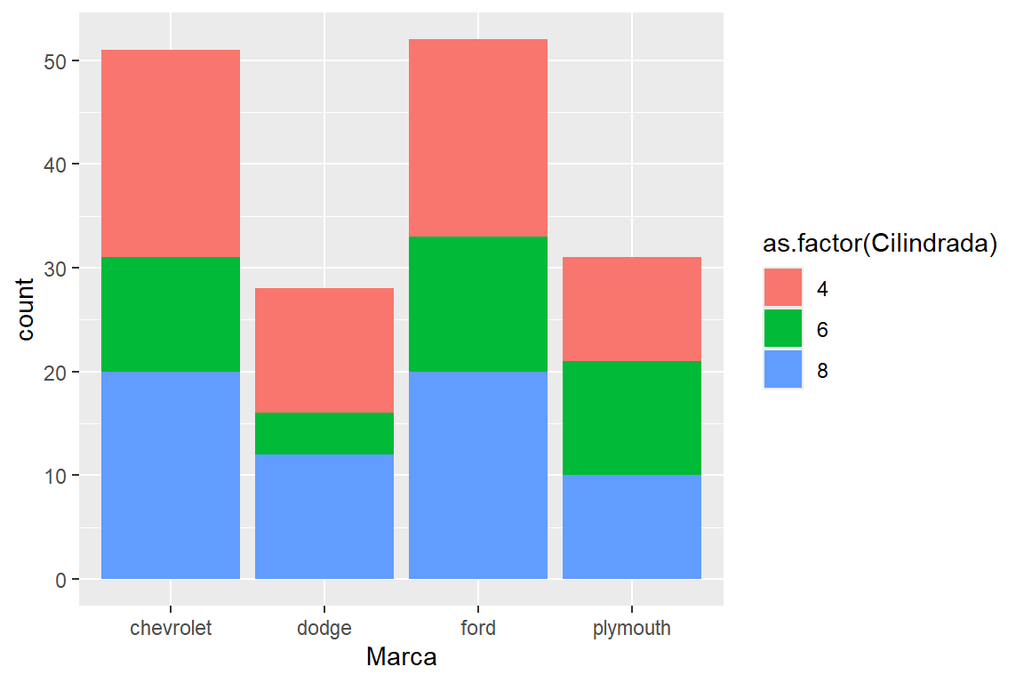

```r
ggplot(data = autos, aes(x = Marca, fill = as.factor(Cilindrada))) +
  geom_bar()
```

Hacemos el mismo gráfico pero con las barras agrupadas, no apiladas. Además, configuramos los colores de la barra.

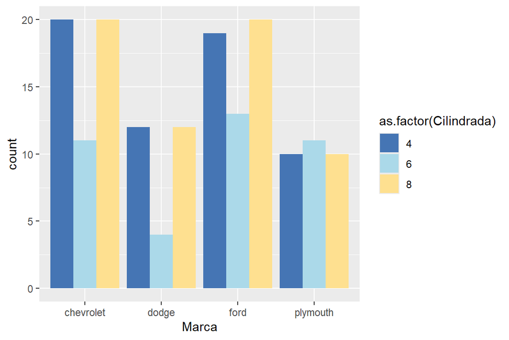

```r
ggplot(data = autos, aes(x = Marca, fill = as.factor(Cilindrada))) +
  geom_bar(position = "dodge") + scale_fill_manual(values = c("#4575B4", "#ABD9E9", "#FEE090", "#F46D43"))
```

Gráfico de mosaico

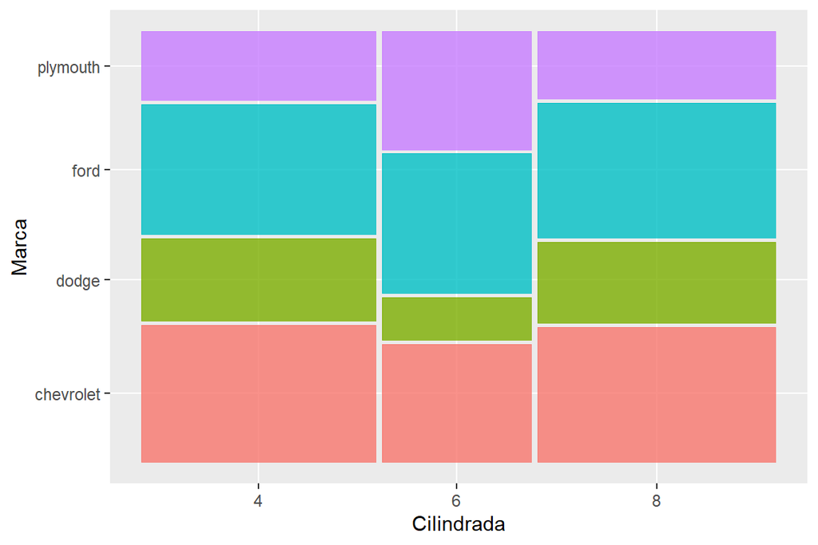

```r
library(ggmosaic)
ggplot(autos) +
  geom_mosaic(aes(x = product(Cilindrada), fill=Marca), show.legend = FALSE)
```